# Data Exploration

Andrea Odell

11/24/2020

## Exploring the Data

```r
lingcod <- read.csv("data/Lingcod with Gut Contents_All_BB.csv")
colnames(lingcod)
```

```
##   [1] "Sample.ID"
##   [2] "Ages"
##   [3] "Method"
##   [4] "Date..yymmdd."
##   [5] "Port"
##   [6] "Location"
##   [7] "MPA.1.fish.take.prohibited."
##   [8] "Vessel"
##   [9] "Angler.no"
##  [10] "Drift.no"
##  [11] "Time.min"
##  [12] "BAIT.USED"
##  [13] "Lat"
##  [14] "Long"
##  [15] "Depth.ft"
```

[output cut: 236 more lines]

## Duplicate Columns for sex

There were two columns for sex, and it looks like they don’t align perfectly. Why not? What’s the difference between the two? Which one should I use?

```r
  lingcod_sexColumns <- lingcod %>%
  select(Sample.ID, Sex, Sex.1)

lingcod_sexColumns %>%
  group_by(Sex) %>%
  tally()
```

```
## # A tibble: 5 x 2
##   Sex       n
##   <chr> <int>
## 1 ""       55
## 2 "F"     620
## 3 "M"     698
## 4 "U"       2
## 5  <NA>     1
```

```r
lingcod_sexColumns %>%
  group_by(Sex.1) %>%
  tally()
```

```
## # A tibble: 4 x 2
##   Sex.1     n
##   <chr> <int>
## 1 ""       55
## 2 "F"     630
## 3 "M"     690
## 4  <NA>     1
```

There are 1321 total observations. 165 of which contained sebastes in stomach content

## Create working dataset

- I chose to use the “Sex.1” column rather than “Sex” because it corrected the “U” sex observations in the “Sex” column.
- I select columns that I believe will be relevant to the project.
- I create a new column that sums up stomach content (by weight and number) across all sebastes species.
- I filtered out any rows where Sex.1 is blank because all values in the row were 0
- Replaced all 0’s in Ages column with NAs

```r
lingcod_rockfish <- lingcod %>%
  select(Sample.ID, Ages, Date..yymmdd., Port, Location, Lat, Long,
         Depth.ft, TL.cm, Sex.1, Wt.kg, Gape, Maturity, Stage,
         Gut.wt.kg, Gut.contents.kg, X..Sebastes, wt..Sebastes,
         X..Sebastes.jordani, wt..Sebastes.jordani, X..Yellowtail.Rockfish,
         wt..Yellowtail.Rockfish, X..Blue.Rockfish, wt..Blue.Rockfish,
         X..Black.Rockfish, wt..Black.RF, X..Puget.Sound.Rockfish,
         wt..Puget.Sound.Rockfish) %>%
  replace(is.na(.), 0) %>%
  mutate(X..Sebastes.Total = rowSums(select(.,X..Sebastes, X..Sebastes.jordani,
                                            X..Yellowtail.Rockfish, X..Blue.Rockfish,
                                            X..Black.Rockfish, X..Puget.Sound.Rockfish))) %>%
  mutate(wt..Sebastes.Total = rowSums(select(.,wt..Sebastes, wt..Sebastes.jordani,
                                             wt..Yellowtail.Rockfish, wt..Blue.Rockfish,
                                             wt..Black.RF, wt..Puget.Sound.Rockfish))) %>%
  filter(Sex.1 != "")

### Replace all 0s in Ages column with NAs
lingcod_rockfish$Ages <- replace(lingcod_rockfish$Ages, lingcod_rockfish$Ages == 0, NA)
```

## Missing Ages Values

There are 189 observations with missing Ages values (~14% of the data). It might be worth estimating their ages based off of lengths (in cm) or weights (in kg). I created a table with the range of length values for each Age, including the total number of observations in that age class

```r
lingcod_rockfish %>%
  group_by(Ages) %>%
  summarise(
    MaxLengthByAge = max(TL.cm, na.rm = T),
    MinLengthByAge = min(TL.cm, na.rm = T),
    MeanLengthByAge = mean(TL.cm, na.rm = T),
    n = n()
  ) %>%
  arrange(Ages)
```

```
## # A tibble: 17 x 5
##     Ages MaxLengthByAge MinLengthByAge MeanLengthByAge     n
##    <dbl>          <dbl>          <dbl>           <dbl> <int>
##  1     1           27             27              27       1
##  2     2           69.3           33.1            45.5    33
##  3     3           77.5           33.8            53.8   176
##  4     4           88.5            0              62.1   209
##  5     5           90.7           50.4            66.7   164
##  6     6           91.8           53.4            71.0   205
##  7     7          102.            55.5            79.2   160
##  8     8           97.8           58              82.2    94
##  9     9          105             59.3            86.3    40
## 10    10          101.            71.3            89.0    20
## 11    11          107             67.2            87.9    14
## 12    12          111             79              93       8
## 13    13          104.            81.9            96.6     3
## 14    15          115             99.5           106.      3
## 15    16          113            113             113       1
## 16    17          112            112             112       1
## 17    NA           97.4           42              64.8   189
```

## Data Visualization

Let’s look at how Length Varies with Age between Males and Females

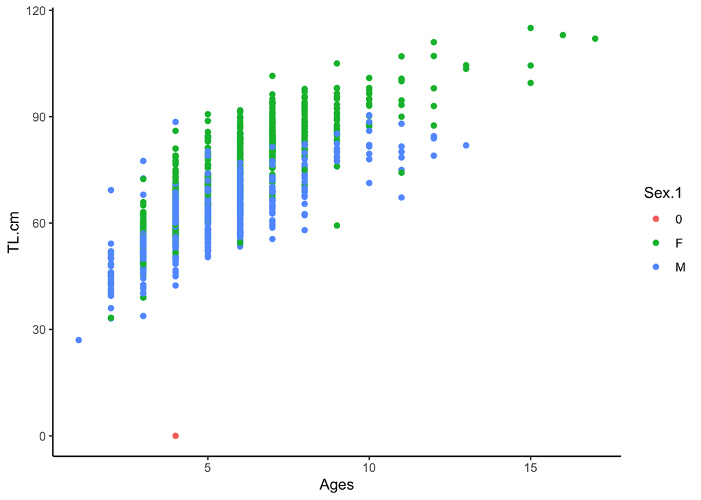

```r
ggplot(lingcod_rockfish, aes(x = Ages, y = TL.cm, color = Sex.1)) +
  geom_point() +
  theme_classic()
```

How much sebastes by weight was found in each age class. Fewer points because only 165 observations with sebastes gut content > 0

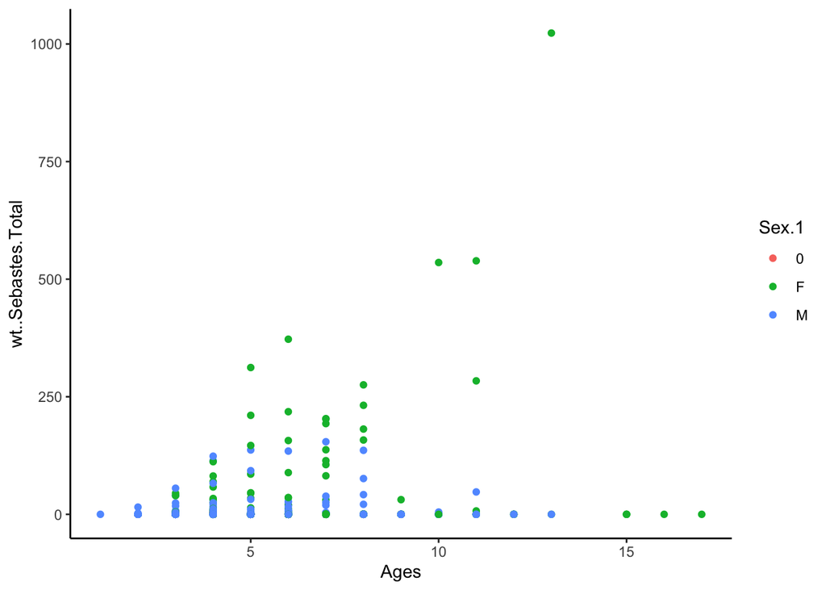

```r
ggplot(lingcod_rockfish, aes(x = Ages, y = wt..Sebastes.Total, color = Sex.1)) +
  geom_point() +
  theme_classic()
```

How Age varies with Depth

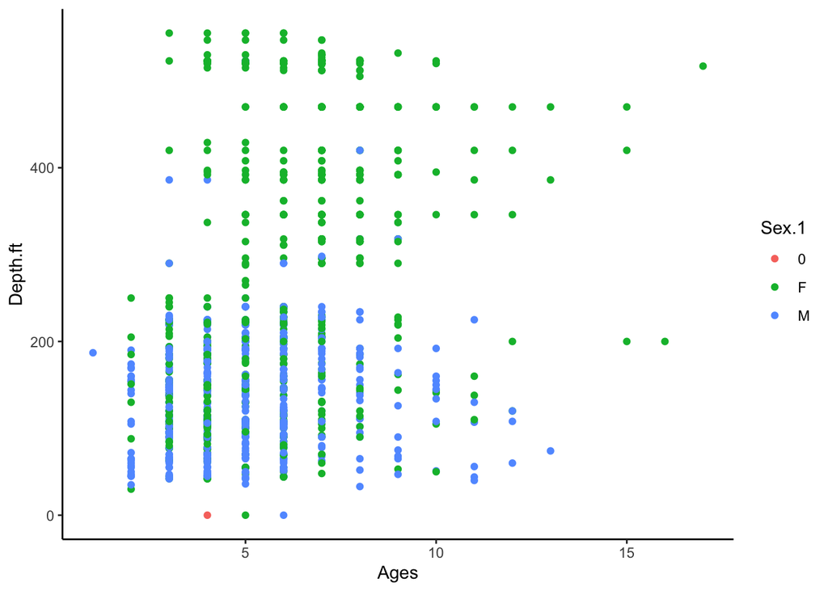

```r
ggplot(lingcod_rockfish, aes(x = Ages, y = Depth.ft, color = Sex.1)) +
  geom_point() +
  theme_classic()
```